# Final Exam Winter 2020

Data Science for Managers

Due by midnight: 22 April 2020

Submit an R Markdown file for the following five problems. In order to get full credit, your R Markdown document must knit properly and you shouldn’t use any software other than R to complete your calculations.

## Problem 1 Violin Plot

Create the following violin plot for the hwy and cty variables from the mpg tibble.

- Include the mean as part of your violin plot
- Use the Pastel1 brewer palette
- Carefully label the graph so that yours matches the violin plot shown.

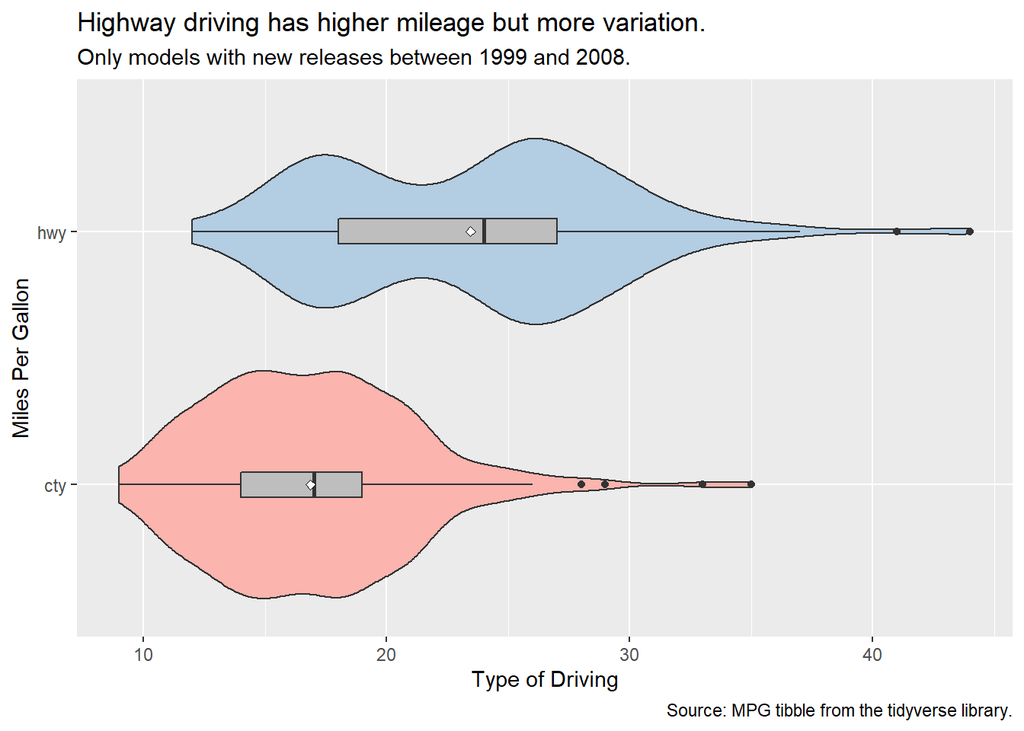

```r
mpg %>%
  select(hwy, cty) %>%
  pivot_longer(cols = c(hwy, cty),
               names_to = "Type_of_Driving",
               values_to = "Miles_Per_Gallon") %>%
  ggplot(aes(x = Miles_Per_Gallon,
             y = Type_of_Driving,
             fill = Type_of_Driving)) +
  geom_violin(show.legend = FALSE) +
  geom_boxplot(fill = "grey",
               width = 0.10,
               show.legend = FALSE) +
  stat_summary(
    fun = "mean",
    geom = "point",
    shape = 23,
    size = 1.5,
    fill = "white"
  ) +
  scale_fill_brewer(palette = "Pastel1") +
  labs(
    title = "Highway driving has higher mileage but more variation.",
    subtitle = "Only models with new releases between 1999 and 2008.",
    x = "Type of Driving",
    y = "Miles Per Gallon",
    caption = "Source: MPG tibble from the tidyverse library."
  )
```

## Problem 2 top 5 destinations

- Calculate the number of flights leaving from JFK for each destination airport.
- Sort the destinations in descending order and choose the top 5 destinations.
- Save the tibble so that it can be used in the next problem.
- Print the top five airports.

```r
(top_five <- flights %>%
  filter(origin == "JFK") %>%
  group_by(dest) %>%
  count(dest) %>%
  arrange(desc(n)) %>%
  head(5)
)
```

```
## # A tibble: 5 x 2
## # Groups:   dest [5]
##   dest      n
##   <chr> <int>
## 1 LAX   11262
## 2 SFO    8204
## 3 BOS    5898
## 4 MCO    5464
## 5 SJU    4752
```

## Problem 3 Bar chart with filtering

- Use the tibble from Problem 2 and a filtering join to select only those rows from the flights tibble that fly to the top five destinations. If you haven’t been able to complete Problem 2 successfully, then email me and I will send you the tibble you need to complete this problem.
- Choose only those flights that leave from JFK.
- Create a horizontal Pareto chart with the largest frequency (LAX) at the top of the graph.
- Use the Pastel2 brewer palette.
- Optionally, if you are looking for an additional challenge, you could also use a mutating join to add the airport names to your graph rather than the codes (LAX is Los Angeles).

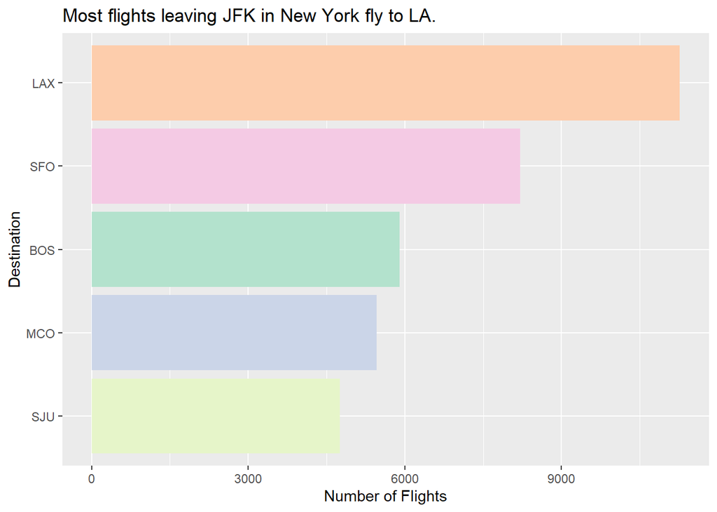

```r
flights %>%
  semi_join(top_five) %>%
  filter(origin == "JFK") %>%
  ggplot(aes(y = fct_infreq(dest) %>% fct_rev(), fill = dest)) +
  geom_bar(show.legend = FALSE) +
  scale_fill_brewer(palette = "Pastel2") +
  labs(
    title = "Most flights leaving JFK in New York fly to LA.",
    x = "Number of Flights",
    y = "Destination"
  )
```

## Problem 4

Write a function that identifies the size of the most deviant observations in a numerical vector as defined by the largest absolute value of the z-score.

- Calculate the deviation from the mean.
- Calculate the z-score by dividing each deviation by the standard deviation.
- Calculate the absolute value of each z-score.
- Find the largest absolute z-score and round the result to two decimal places.
- Test your function on the hwy column from the mpg tibble.
- Optional: Show that you can accomplish the same thing with one line of code in the body by using the **scale()** function.

```r
most_deviant <- function(x) {
  deviation <- x - mean(x)
  z_score <- deviation / sd(x)
  z_score %>% abs() %>% max() %>% round(2)
}
```

The z-score for the most deviant observation in the hwy column in the mpg tibble is: `3.45`

```r
most_deviant_efficient <- function(x) {
  scale(x) %>% abs() %>% max() %>% round(2)
}
```

The z-score for the most deviant observation in the hwy column in the mpg tibble that is found by using the scale function is: `3.45`

## Problem 5 Loops and mapping functions

1. Demonstrate how to use glimpse to find that the numerical variables in mpg are cyl, displ, cty, and hwy.
2. Create a new tibble that includes only the numerical columns from mpg.
3. Use a for loop and your function from problem 4 to find the most deviant absolute z-score for each numerical column in the mpg tibble. If you have struggled with the function in Problem 4, email me and I will send you the answer.
4. Use a map function to accomplish the same thing as the previous step.
5. Print out your z-scores from your loop and from using map.

```r
mpg %>% glimpse()
```

```
## Rows: 234
## Columns: 11
## $ manufacturer <chr> "audi", "audi", "audi", "audi", "audi", "audi", "audi"...
## $ model        <chr> "a4", "a4", "a4", "a4", "a4", "a4", "a4", "a4 quattro"...
## $ displ        <dbl> 1.8, 1.8, 2.0, 2.0, 2.8, 2.8, 3.1, 1.8, 1.8, 2.0, 2.0,...
## $ year         <int> 1999, 1999, 2008, 2008, 1999, 1999, 2008, 1999, 1999, ...
## $ cyl          <int> 4, 4, 4, 4, 6, 6, 6, 4, 4, 4, 4, 6, 6, 6, 6, 6, 6, 8, ...
## $ trans        <chr> "auto(l5)", "manual(m5)", "manual(m6)", "auto(av)", "a...
## $ drv          <chr> "f", "f", "f", "f", "f", "f", "f", "4", "4", "4", "4",...
## $ cty          <int> 18, 21, 20, 21, 16, 18, 18, 18, 16, 20, 19, 15, 17, 17...
## $ hwy          <int> 29, 29, 31, 30, 26, 26, 27, 26, 25, 28, 27, 25, 25, 25...
## $ fl           <chr> "p", "p", "p", "p", "p", "p", "p", "p", "p", "p", "p",...
## $ class        <chr> "compact", "compact", "compact", "compact", "compact",...
```

```r
mpg_numeric <- mpg %>%
  select(displ, cty, hwy, cyl)

deviant_values <- vector("numeric", length(mpg_numeric))
for (i in seq_along(mpg_numeric)) {
  deviant_values[[i]] <- mpg_numeric[[i]] %>% most_deviant()
}

from_map <- mpg_numeric %>%
  map_dbl(most_deviant)
```

The largest absolute z-scores found using a loop are:

```r
deviant_values
```

```
## [1] 2.73 4.26 3.45 1.31
```

The largest absolute z-scores found using map are:

```r
from_map
```

```
## displ   cty   hwy   cyl
##  2.73  4.26  3.45  1.31
```

## Optional if you want another challenge, arrange the loop and map results into a single tibble.

- Use column names from from your tibble of numerical variables.
- Get the values for the second column from the results of your loop.
- Get the values for the third column from the results of your map.
- Print out the resulting tibble.

```r
results <- tibble(Variables = colnames(mpg_numeric), From_Loop = deviant_values, From_Map = from_map)
results
```

```
## # A tibble: 4 x 3
##   Variables From_Loop From_Map
##   <chr>         <dbl>    <dbl>
## 1 displ          2.73     2.73
## 2 cty            4.26     4.26
## 3 hwy            3.45     3.45
## 4 cyl            1.31     1.31
```